# Act Report : WeRateDogs Twitter Data

This report communicates the insights and displays the visualization produced from the wrangled data.

## Which source is used to tweet the most?

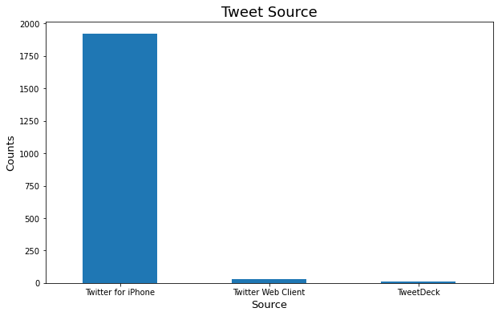

## Trend of retweets overtime?

I got curious about the trend of retweets and likes over the period of the data. I wondered if the trend of *retweets* will match with the trend of *likes*. Hence, I decided to look at both the rewteets and likes separately then I checked their correlation.

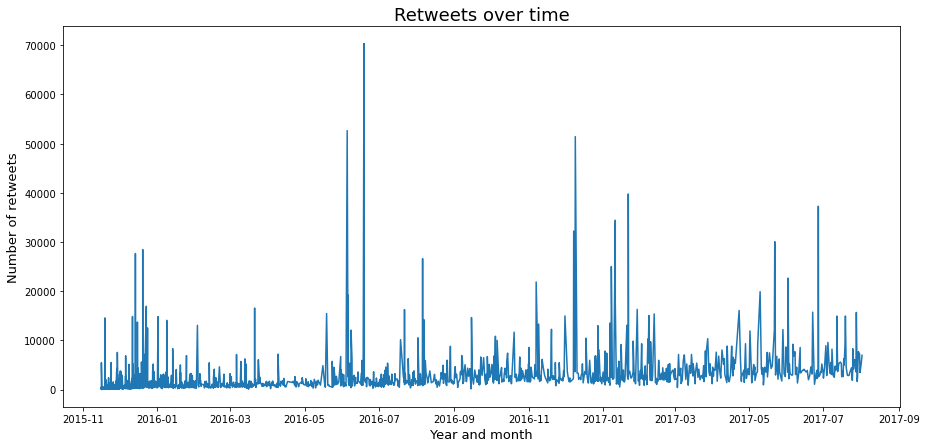

## Trend of likes overtime?

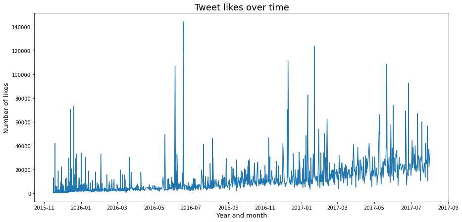

Looking at the two timeseries display above, it can be deduced that retweet count and favorite count share a significant positive correlation. The scatter plot below shows this.

## What kind of relationship is between favorite count and retweet count?

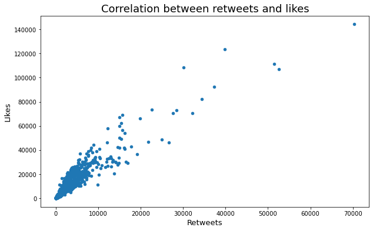

It is evident that as retweets increase, so does likes and vice versa. Hence the significant **upward movement** of the plot.

## Which dog stage are most dogs at?

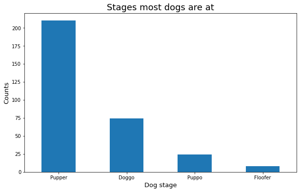

## What are the top 10 dog names?

I displayed the top **ten (10)** common names given to dogs below using the barh chart.

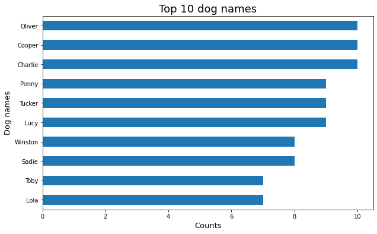

Through my analysis and visualization efforts I have been able to answer the questions below:

- Which source is used to tweet the most?
- Trend of retweets overtime?
- Trend of tweet likes overtime?
- What kind of relationship is between favorite count and retweet count?
- Which dog stage are most dogs at?
- What are the top 10 dog names?

The code is in the **Visualization** subsection in the **‘Analyzing and Visualizing Data’** section of the `wrangle_act.ipynb notebook`.